# R Notebook

markchafin

4/19/21

# 1

```
Show the structure and head of the mtcars dataset. We focus on the following two variables:
```

mpg: miles per gallon am: transmission (0 = automatic, 1 = manual)

```r
rm(list = ls())
library(dplyr)
```

```r
library(ggplot2)

str(mtcars)
```

```
## 'data.frame':    32 obs. of  11 variables:
##  $ mpg : num  21 21 22.8 21.4 18.7 18.1 14.3 24.4 22.8 19.2 ...
##  $ cyl : num  6 6 4 6 8 6 8 4 4 6 ...
##  $ disp: num  160 160 108 258 360 ...
##  $ hp  : num  110 110 93 110 175 105 245 62 95 123 ...
##  $ drat: num  3.9 3.9 3.85 3.08 3.15 2.76 3.21 3.69 3.92 3.92 ...
##  $ wt  : num  2.62 2.88 2.32 3.21 3.44 ...
##  $ qsec: num  16.5 17 18.6 19.4 17 ...
##  $ vs  : num  0 0 1 1 0 1 0 1 1 1 ...
##  $ am  : num  1 1 1 0 0 0 0 0 0 0 ...
##  $ gear: num  4 4 4 3 3 3 3 4 4 4 ...
##  $ carb: num  4 4 1 1 2 1 4 2 2 4 ...
```

```r
head(mtcars)
```

|  | mpg | cyl | disp | hp | drat | wt | qsec | vs | am | gear | carb |
| --- | --- | --- | --- | --- | --- | --- | --- | --- | --- | --- | --- |
| Mazda RX4 | 21.0 | 6 | 160 | 110 | 3.90 | 2.620 | 16.46 | 0 | 1 | 4 | 4 |
| Mazda RX4 Wag | 21.0 | 6 | 160 | 110 | 3.90 | 2.875 | 17.02 | 0 | 1 | 4 | 4 |
| Datsun 710 | 22.8 | 4 | 108 | 93 | 3.85 | 2.320 | 18.61 | 1 | 1 | 4 | 1 |
| Hornet 4 Drive | 21.4 | 6 | 258 | 110 | 3.08 | 3.215 | 19.44 | 1 | 0 | 3 | 1 |
| Hornet Sportabout | 18.7 | 8 | 360 | 175 | 3.15 | 3.440 | 17.02 | 0 | 0 | 3 | 2 |
| Valiant | 18.1 | 6 | 225 | 105 | 2.76 | 3.460 | 20.22 | 1 | 0 | 3 | 1 |

```r
df <- select(mtcars, 1, 9)

mtcars$am <- as.factor(mtcars$am)
levels(mtcars$am) <- c("Automatic", "Manual")
```

# 2

We want to visualize the difference of mpg between two types of transmission. Draw a boxplot of mpg grouped by transmission type (two boxplots on the same figure, each representing one transmission type) (2pts).

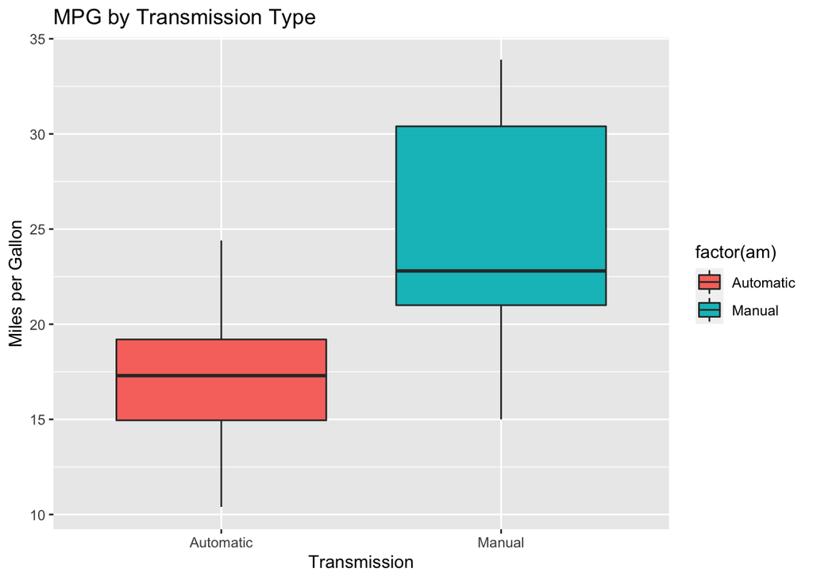

```r
ggplot(mtcars, aes(x=factor(am),y=mpg,fill=factor(am)))+
  geom_boxplot(notch=F)+
  scale_x_discrete("Transmission")+
  scale_y_continuous("Miles per Gallon")+
  ggtitle("MPG by Transmission Type")
```

# 3 What conclusion could you get from the above boxplot (2pts)? Manual transmissions have a higher fuel efficiency # 4 Now we want to use hypothesis testing method to test if manual transmission cars have better miles per gallon than automatic transmission cars. Specify your null and alternative hypothesis (4pts).

H0 mean(manualdata$mpg) < mean(autodata$mpg) Ha mean(manualdata$mpg) > mean(autodata$mpg)

```r
autoData <- mtcars[mtcars$am == "Automatic",]
manualData <- mtcars[mtcars$am == "Manual",]
ttest <- t.test(autoData$mpg, manualData$mpg, alternative = "less", mu = 0)
ttest
```

```
##
##  Welch Two Sample t-test
##
## data:  autoData$mpg and manualData$mpg
## t = -3.7671, df = 18.332, p-value = 0.0006868
## alternative hypothesis: true difference in means is less than 0
## 95 percent confidence interval:
##       -Inf -3.913256
## sample estimates:
## mean of x mean of y
##  17.14737  24.39231
```

```r
autoData <- mtcars[mtcars$am == "Automatic",]
manualData <- mtcars[mtcars$am == "Manual",]
ttest <- t.test(autoData$mpg, manualData$mpg, alternative = "greater", mu = 0)
ttest
```

```
##
##  Welch Two Sample t-test
##
## data:  autoData$mpg and manualData$mpg
## t = -3.7671, df = 18.332, p-value = 0.9993
## alternative hypothesis: true difference in means is greater than 0
## 95 percent confidence interval:
##  -10.57662       Inf
## sample estimates:
## mean of x mean of y
##  17.14737  24.39231
```

```r
t.test(mpg~am, data = mtcars)
```

```
##
##  Welch Two Sample t-test
##
## data:  mpg by am
## t = -3.7671, df = 18.332, p-value = 0.001374
## alternative hypothesis: true difference in means is not equal to 0
## 95 percent confidence interval:
##  -11.280194  -3.209684
## sample estimates:
## mean in group Automatic    mean in group Manual
##                17.14737                24.39231
```

```r
t.test(autoData$mpg, data = autoData)
```

```
##
##  One Sample t-test
##
## data:  autoData$mpg
## t = 19.495, df = 18, p-value = 1.497e-13
## alternative hypothesis: true mean is not equal to 0
## 95 percent confidence interval:
##  15.29946 18.99528
## sample estimates:
## mean of x
##  17.14737
```

```r
t.test(manualData$mpg, data = manualData)
```

```
##
##  One Sample t-test
##
## data:  manualData$mpg
## t = 14.262, df = 12, p-value = 6.909e-09
## alternative hypothesis: true mean is not equal to 0
## 95 percent confidence interval:
##  20.66593 28.11869
## sample estimates:
## mean of x
##  24.39231
```

# 5

What is the appropriate hypothesis testing method: one-sample or two-sample (2pts)? Paired or unpaired (2pts)? Why (2pts)? Two-sample, unpaired. the two-sample is required to show the correlation between mpg and transmission (am) and you can’t do a paired test unless you clean the data and make the sample sizes the same, since the two datasets are not equal. # 6 Use the appropriate method from step 5 to test the hypothesis (2pts).

```r
t.test(mpg~am, data = mtcars, alternative = "less")
```

```
##
##  Welch Two Sample t-test
##
## data:  mpg by am
## t = -3.7671, df = 18.332, p-value = 0.0006868
## alternative hypothesis: true difference in means is less than 0
## 95 percent confidence interval:
##       -Inf -3.913256
## sample estimates:
## mean in group Automatic    mean in group Manual
##                17.14737                24.39231
```

# 7

Explain the hypothesis result (2pts). My hypothesis results show the manual cars have a higher mpg than automatic cars. This data is from 1974 Motor Trend US magazine. Todays data could be different.

# 8

Knit your R Markdown file into an HTML file and upload both R Markdown file and associated HTML file to Canvas (2pts).